# AOOI3_Aula02_ConceitosIniciais-Abstracoes

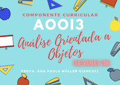

Instituto Federal de São Paulo (IFSP)  
[Campus Bragança Paulista/SP](https://bra.ifsp.edu.br)  
**Análise e Desenvolvimento de Sistemas (ADS)**  
**3o. módulo**  
**Profa. Ana Paula Müller Giancoli**  
paulagiancoli@ifsp.edu.br

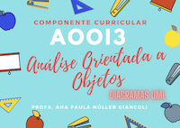

## AULA 02 - CONCEITOS INICIAIS E ABSTRAÇÕES

### Agenda

- O que são objetos
- O que são classes
- O que são atributos
- O que são métodos
- O que são abstrações
- Algumas técnicas de Orientação a Objetos
- Perguntas

### 1. O que são objetos

- São elementos que podemos:
  - manipular,
  - acompanhar seu comportamento,
  - criar,
  - interagir com ele ou até mesmo, destruí-lo.
- Podem existir no mundo real ou derivarem de outros objetos.
- **Exemplos**: máquina, organizações, negócio etc.

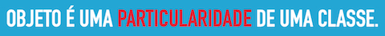

### 2. O que são classes

- São descrições de um conjunto de objetos comuns. Todos os objetos de uma classe possuem:
  - uma **identidade** —> atributo.
  - um **estado** —> dados associados ao objeto em vários.
  - momentos na execução de uma funcionalidade, um **comportamento** —> são as ações ou métodos.
- **Classe** é um tipo definido pelo usuário que possui especificações (características e comportamentos) que o identifiquem.
- **Classe** é o *molde* que será usado para construir objetos que representam a vida real.
- **O *molde* é gerado por meio de observações**.

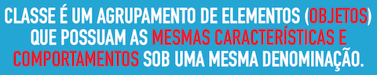

### 3. O que são atributos

- São definições das características de um objeto.
- Os atributos armazenam os dados (informações) do objeto.
- Os atributos são declarados dentro de uma classe e são informados o seu tipo de dado a ser armazenado.

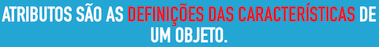

### 4. O que são métodos

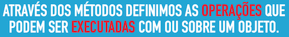

### 5. O que são abstrações

- São processos mentais pelo qual nós, seres humanos, nos atemos aos aspectos mais importantes.
- Imaginamos o que esse objeto real irá realizar dentro do nosso sistema.
- **O objeto precisará ter**: identidade, propriedades, métodos.

### 6. Técnicas de Orientação a Objetos

| Técnicas |
| --- |
| 1. Encapsulamento. |
| 2. Polimorfismo. |
| 3. Coesão. |
| 4. Acoplamento. |
| 5. Herança. |

### 6.1. Encapsulamento

- É uma das **principais técnicas de programação orientada a objetos**.
- **Adiciona segurança à aplicação**, escondendo as propriedades.
- É uma forma de restringir o acesso ao comportamento interno de um objeto.
- Quando um objeto necessita da colaboração de outro objeto, ele solicita por meio de mensagens, eventos, ações.
- O método utilizado pelo objeto requisitado não é de conhecimento de quem solicitou.
- O importante é que a operação seja executada, não importando como.
- Nas linguagens de programação são implementadas por meio de propriedades privadas, e são acessadas por métodos getters e setters.
- **Exemplos**: Pressionar um botão de uma TV. Pressionar o freio do carro.
  - **Encapsular é fundamental** para que seu sistema seja suscetível a mudanças:
    - Não precisamos mudar uma regra de negócio em vários lugares, mas sim em apenas um único lugar, já que essa regra está encapsulada.
    - Quando utilizamos os **underscores estamos alertando para não ler diretamente** aquele atributo ou mesmo modificá-lo diretamente. Para isso, **utilizar os métodos de acesso get e set**.
    - Aprofunde o assunto, lendo [Prof. Marcolan](https://professormarcolan.com.br/encapsulamento-em-python/).

### 6.1.1. Exemplificando com a Linguagem de Programação Python

#### Fracamente

- O Python não utiliza o **termo private**, que é **um modificador de acesso** e também chamado de **modificador de visibilidade**.
- Existe uma **convenção**:
  - **Métodos e atributos fracamente privados** *são os que possuem um **underscore antes do nome***. Essa abordagem **apenas sinaliza que essas variáveis são privadas e outros programadores não devem utilizá-las em código externos**.
  - Nessa situação **conseguimos fazer o acesso de *fora* da classe**.

```python
# Exemplo
class Pessoa:

    def __init__(self, nome, idade):
        """Inicializa os atributos que descrevem uma pessoa."""
        self.nome = nome
        self.idade = idade

    def get_nome(self):
        return self.nome

    def get_idade(self):
        return self.idade

nova_pessoa = Pessoa('Carlos Alberto', 80)
print(nova_pessoa.nome)
print(nova_pessoa.idade)
print(nova_pessoa.get_idade())
```

```
Carlos Alberto
80
80
```

```python
# Exemplo
class Pessoa:

    def __init__(self, nome, idade):
        """Inicializa os atributos que descrevem uma pessoa."""
        self.nome = nome
        self._idade = idade        # <------ Inserido um underscore para indicar atributo fracamente privado.

    def get_nome(self):
        return self.nome

    def get_idade(self):
        return self._idade          # <------ Retornando um atributo fracamente privado.

nova_pessoa = Pessoa('Carlos Alberto', 80)
print(nova_pessoa.nome)
print(nova_pessoa._idade)           # <------ Exibindo um atributo fracamente privado.
print(nova_pessoa.get_idade())      # <------ Exibindo um atributo fracamente privado por meio do método get().
```

```
Carlos Alberto
80
80
```

#### **Fortemente**

- **Métodos e atributos fortemente privados** são os que **possuem duplo underscore antes do nome**. Essa abordagem **sinaliza que essas variáveis são privadas. Não é possível acessá-los de forma padrão**.
- Para isso, fazemos o **acesso de fora da classe por**: **nomeInstância._nomeClasse__nomeatributo**. (primeiro é usado um underscore antes do nome da classe, e em seguinda, dois underscores antes do nome do atributo).
- As mesmas regras de acesso aos atributos valem para os **métodos**.

```python
# Exemplo
class Pessoa:

    def __init__(self, nome, idade):
        """Inicializa os atributos que descrevem uma pessoa."""
        self.nome = nome
        self.__idade = idade        # <------ Inserido um underscore para indicar atributo fortemente privado.

    def get_nome(self):
        return self.nome

    def get_idade(self):
        return self.__idade          # <------ Retornando um atributo fortemente privado.

nova_pessoa = Pessoa('Carlos Alberto', 80)
print(nova_pessoa.nome)
print(f'Idade = {nova_pessoa.get_idade()}.')           # <------ Exibindo um atributo fortemente privado.
print(nova_pessoa._Pessoa__idade)      # <------ Exibindo um atributo fortemente privado por meio da classe.
```

```
Carlos Alberto
Idade = 80.
80
```

### 6.2. Polimorfismo

- É a **capacidade de abstrair várias implementações diferentes em uma única interface**.
- É a **capacidade de duas ou mais classes de objetos** responderem à mesma mensagem, cada uma ao seu próprio modo.
- **Exemplo**: Editor gráfico, operação. Classe Retângulo, Classe Círculo, Classe Quadrado.
  - Ao solicitar ao editor gráfico para desenhar uma figura, a operação é passada para as classes que executam a ação, desenham seus próprios objetos, retângulo, elipse, quadrado.
  - Consulte a página do [Professor Marcolan](https://professormarcolan.com.br/polimorfismo-em-python/) para maiores informações.

### 6.1.1. Exemplificando com a Linguagem de Programação Python

```python
# Exemplo de implementacão de classe abstrata
class FormaGeometrica:

    def calcular_area(self):
        pass
```

```python
# Exemplo da implementação de classes concretas.
# Foram criados dois métodos para cada classe que representa uma Figura Geométrica.
# O método __init__ responsável por construir os objetos da classe.
# O método calcular_area responsável por efetuar o cálculo da área conforme a Figura Geométrica, porém, utiliza
# o mesmo método definido na classe abstrata com suas devidas particularidades.
# O cálculo da área será feito para cada Figura, segundo seu comportamento.
import math
class Retangulo(FormaGeometrica):
    def __init__(self, base, altura):
        self.base = base
        self.altura = altura

    def calcular_area(self):
        figura = ['Retângulo']
        figura.append(self.base * self.altura)
        return figura


class Circulo(FormaGeometrica):
    def __init__(self, raio):
        self.raio = raio

    def calcular_area(self):
        figura = ['Círculo']
        figura.append(self.raio * self.raio * math.pi)
        return figura


class Quadrado(FormaGeometrica):
    def __init__(self, base):
        self.base = base

    def calcular_area(self):
        figura = ['Quadrado']
        figura.append(self.base * self.base)
        return figura
```

```python
# Exemplo do uso do Polimorfismo.
# A variável retangulo1 representa um retângulo de base 4cm e altura 8cm.
# A variável retangulo2 representa um retângulo de base 6cm e altura 10cm.
# A variável quadrado1 representa um quadrado com 4cm de lado.
# A variável quadrado2 representa um quadrado com 6cm de lado.
# A variável circulo1 representa um círculo de 4cm de raio.
# A variável circulo2 representa um círculo de 6cm de raio.
# A variável formas_geometricas armazena uma lista de figuras.

retangulo1 = Retangulo(4, 8)
retangulo2 = Retangulo(6, 10)
quadrado1 = Quadrado(4)
quadrado2 = Quadrado(6)
circulo1 = Circulo(4)
circulo2 = Circulo(6)

formas_geometricas = [retangulo1, retangulo2, quadrado1, quadrado2, circulo1, circulo2]

area = 0
for i, forma in enumerate(formas_geometricas):
    area = forma.calcular_area()
    print(f"A área da Figura {i} - {area[0]} foi de {round(area[1], 2)} m2.")
```

```
A área da Figura 0 - Retângulo foi de 32 m2.
A área da Figura 1 - Retângulo foi de 60 m2.
A área da Figura 2 - Quadrado foi de 16 m2.
A área da Figura 3 - Quadrado foi de 36 m2.
A área da Figura 4 - Círculo foi de 50.27 m2.
A área da Figura 5 - Círculo foi de 113.1 m2.
```

### 6.3. Coesão

- Indica que **uma classe deve cuidar ou tentar cuidar de todas as informações e ações de sua responsabilidade**.
- *Quanto mais você encapsula as informações, responsabilidades dentro de uma classe, mais esta classe está coesa*.
- Ocorre **sobre uma classe**.
- Para que uma classe seja coesa e reutilizável, ela não deve possuir mais de uma responsabilidade.
- De acordo com [Chan, Vinicius (2019)](https://medium.com/@viniciuschan/solid-com-python-entendendo-os-5-princ%C3%ADpios-na-pr%C3%A1tica-f2af330b7751), em diversas situações há a necessidade de inserirmos alguma propriedade, algum método em uma classe já definida e por não existir outro local adequado para isso. Entretanto, ao efetuarmos esta modificação, estamos alterando o comportamento inicial de uma classe e também, tornando-a ainda mais frágil. Sendo assim, aumentamos o acoplamento e diminuimos a coesão.

```python
# Modificando o exemplo anterior.
# Inserindo o método desenhar a classe Quadrado previamente definida.
# Neste exemplo, estamos aumentando a responsabilidade da classe Quadrado inserindo mais um método.
class Quadrado(FormaGeometrica):
    def __init__(self, base):
        self.base = base

    def calcular_area(self):
        figura = ['Quadrado']
        figura.append(self.base * self.base)
        return figura

    def desenhar(self):
        # Desenha um quadrado
        print("Desenhar quadrado!")
        pass
```

- Para solucionar este problema, a ideia seria criar um nova classe que fosse responsável pelo desenho separadamente da classe responsável pelos cálculos de área.
- Assim mantemos a coesão.

```python
class Desenhar:
    def __init__(self, obj):
        self.obj = obj

    def desenhar(self):
        # Desenha a figura passada no argumento
        pass
```

### 6.4. Acoplamento

- **Ocorre sobre duas ou mais classes**.
- *Quanto mais relacionamentos ou mensagens entre duas classes ou mais, maior é o **acoplamento***.

### 7. Herança

- Podemos utilizar as classes criadas, ou se quisermos criar uma classe especializada, por meio dos conceitos da **Herança**.
- **Quando uma classe herda de outra, ela assume automaticamente os seus atributos e métodos da classe original**, isto é *Herança*.
  - A **classe original** que passará seus atributos e métodos **chama-se classe-pai, classe-mãe, super classe**.
  - E a que **recebe**, é a **classe-filha, subclasse**. A **classe-filha** além de receber os atributos e métodos da **classe-pai**, ela **poderá também, definir seus próprios atributos e métodos**.
- **Exemplos Super Classe**: **Atenção**: Vamos usar a classe criada anteriormente.
  - **Nome da Classe**: FormaGeometrica <---- É a **classe mãe, ou super classe**.
  - **Atributos da super classe**: nenhum.
  - **Métodos da super classe**: calcular_area( ).
- **Exemplos Subclasse**:
  - **Nome da Classe**: Retangulo <---- É a **classe filha, ou subclasse**.
  - **Atributos da subclasse**: base, altura.
  - **Métodos da subclasse**: calcular_area().

#### 2.3.1 Exemplo Herança Múltipla

- Consulte [Programiz](https://www.programiz.com/python-programming/methods/built-in/super)

```python
# Exemplo de Herança Múltipla - herda de mais de uma classe mãe.
class Animal:
    def __init__(self, animalnome):
        print(animalnome, 'é um animal.')


class Mamifero(Animal):
    def __init__(self, mamiferonome):
        print(mamiferonome, 'é um mamífero.')
        super().__init__(mamiferonome)


class Naovoadores(Mamifero):
    def __init__(self, naovoadoresnome):
        print(naovoadoresnome, "não pode voar.")
        super().__init__(naovoadoresnome)


class Naoaquaticos(Mamifero):
    def __init__(self, naoaquaticonome):
        print(naoaquaticonome, "não pode nadar.")
        super().__init__(naoaquaticonome)


class Dog(Naoaquaticos, Naovoadores):
    def __init__(self):
        print('Cachorro tem 4 patas.')
        super(Mamifero, self).__init__('Cachorro')


d = Dog()
print('')
morcego = Naoaquaticos('Morcego')
```

```
Cachorro tem 4 patas.
Cachorro é um animal.

Morcego não pode nadar.
Morcego é um mamífero.
Morcego é um animal.
```

### Referências

- Esta aula foi elaborada a partir do conteúdo disponibilizado em cada um dos links indicados no próprio texto.
- GUEDES, G. T. A. UML 2 - **UMA ABORDAGEM PRÁTICA**. [S.L.]: NOVATEC, 2011.
- MEDEIROS, Ernani - **Desenvolvendo Software com UML 2.0 Definitivo** - Editora Pearson Makron Books.
- BOOCH, Grady; RUMBAUGH, James; JACOBSON, Ivar - **UML Guia do Usuário** - 2a. Edição - Editora Campus (Elsevier).

### Perguntas

- Esclareça suas eventuais dúvidas durante as aulas.
- Ou pelo *E-mail*: paulagiancoli@ifsp.edu.br.
- Ou acesse [Github Ana Giancoli](https://anagiancoli.github.io) e solicite atendimento para o componente curricular.
- Ou pelo *Fórum* do componente curricular.

*ADS - AOO - 3o. módulo*.  
Modelo e formato elaborado por profa. Ana Paula Müller Giancoli - BSD 2-Clause License. - Setembro.2020.